# ggplot2 color scales

Claus O. Wilke

2017-12-06

## Qualitative scales

Qualitative scales contain a discrete set of distinct colors with no implied order.

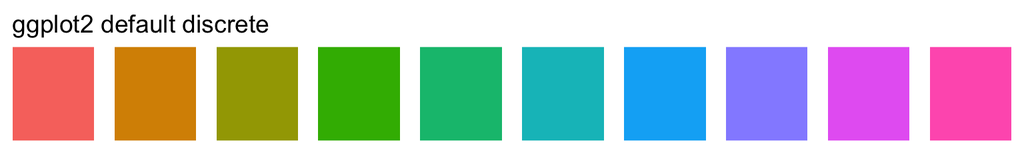

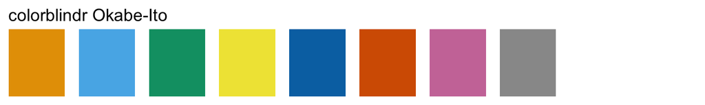

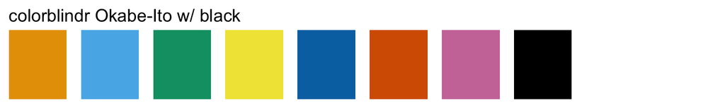

The colorbrewer scales are all called via `scale_fill_brewer(type = "qual", palette = "name")`, where `name` is the name of the palette, e.g. `palette = "Accent"`.

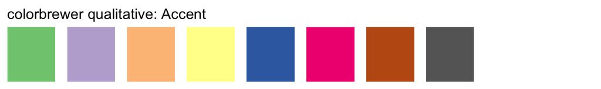

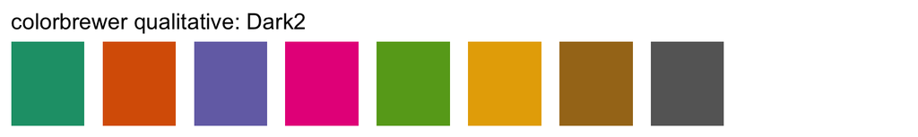

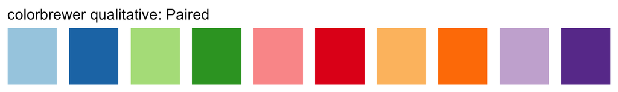

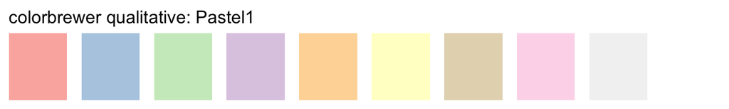

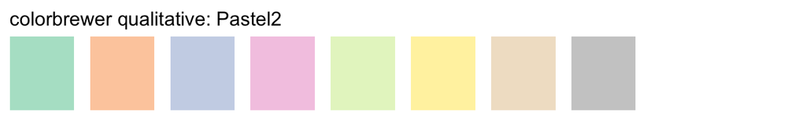

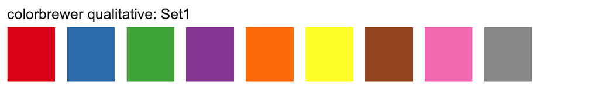

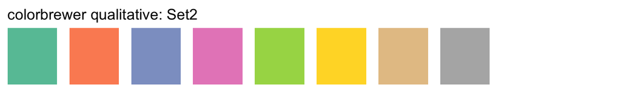

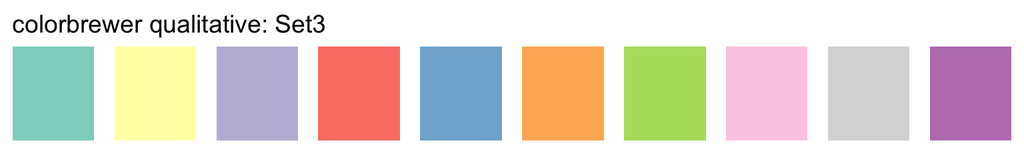

## Sequential scales

Sequential scales convey the ordering or magnitude of an effect. These scales may exist in discrete or continuous forms or both.

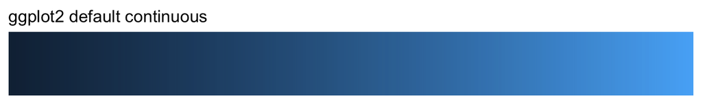

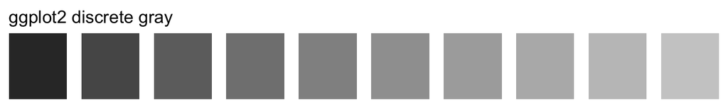

The continuous viridis scales are all called via `scale_fill_viridis(option = "name")`, where `name` is the name of the palette, e.g. `option = "viridis"`.

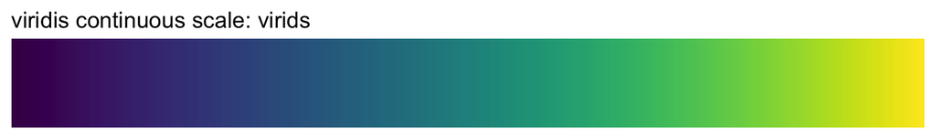

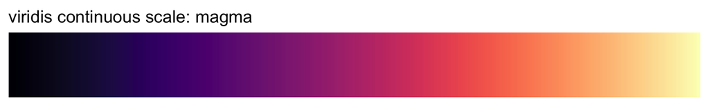

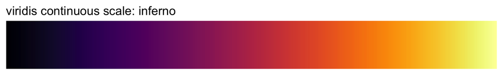

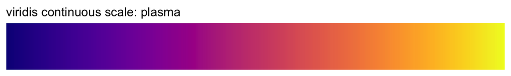

The discrete viridis scales are all called via `scale_fill_viridis(option = "name", discrete = TRUE)`, where `name` is the name of the palette, e.g. `option = "viridis"`.

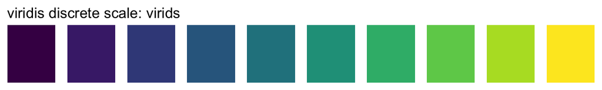

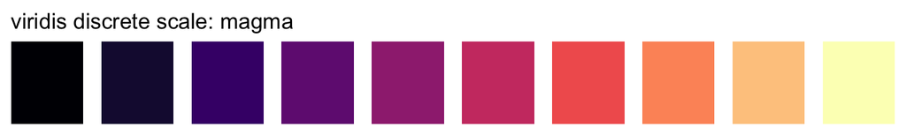

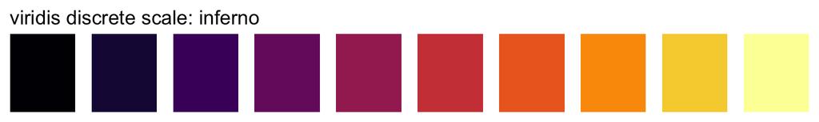

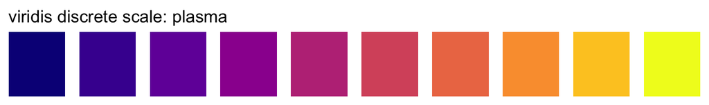

The continuous colorbrewer scales are all called via `scale_fill_distiller(type = "seq", palette = "name")`, where `name` is the name of the palette, e.g. `palette = "Blues"`.

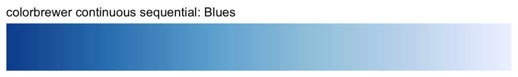